# HW 5

Joe Brew

10/05/2014

The code for the production of this document is available at https://github.com/joebrew/uf.

# Task 1

## For each family address, please find the nearest EMS and calculate the straight-line distance. List the family address ID and EMS ID and the nearest distance below.

(If you use the “Near” tool, please listthe family address ID “OBJECTID,” the EMS ID “NEAR_FID,” and the nearest distance “NEAR_DIST.”" If you use “Generate Near Table,” Please list “IN_FID,” “NEAR_FID” and “NEAR_DIST”).

Set working directory:

```r
if ( Sys.info()["sysname"] == "Linux" ){
  setwd("/home/joebrew/")
} else {
  setwd("C:/Users/BrewJR/")
}

mywd <- paste0(getwd(), "/Documents/uf/phc6194/hw5")
setwd(mywd)
```

Once could read in the mdb file using the Hmisc library and mdb-tools.

```r
# Attach the necessary package
library(Hmisc)

# View which tables are available
mdb.get("Homwork5.mdb", tables = TRUE)

# Read in the Family_address table
fam <- mdb.get("Homwork5.mdb", tables = "Family_address")
gdb <- mdb.get("Homwork5.mdb", tables = "GDB_Items")
road <- mdb.get("Homwork5.mdb", tables = "road")
```

However, the above method doesn’t (easily) keep the spatial aspects associated with each table. Insead, I used ArcGIS to read in the .mdb database, and then exported the road, EMS and addresses shapefiles seperately.

```r
library(rgdal)
road <- readOGR(".", "road")
ems <- readOGR(".", "EMS_LOCATION")
fam <- readOGR(".", "Family_address")
```

Check that our projection and coordinate systems are identical:

```r
proj4string(ems) == proj4string(fam)
```

```
## [1] TRUE
```

Confirm that we read everything in okay by plotting our map and points

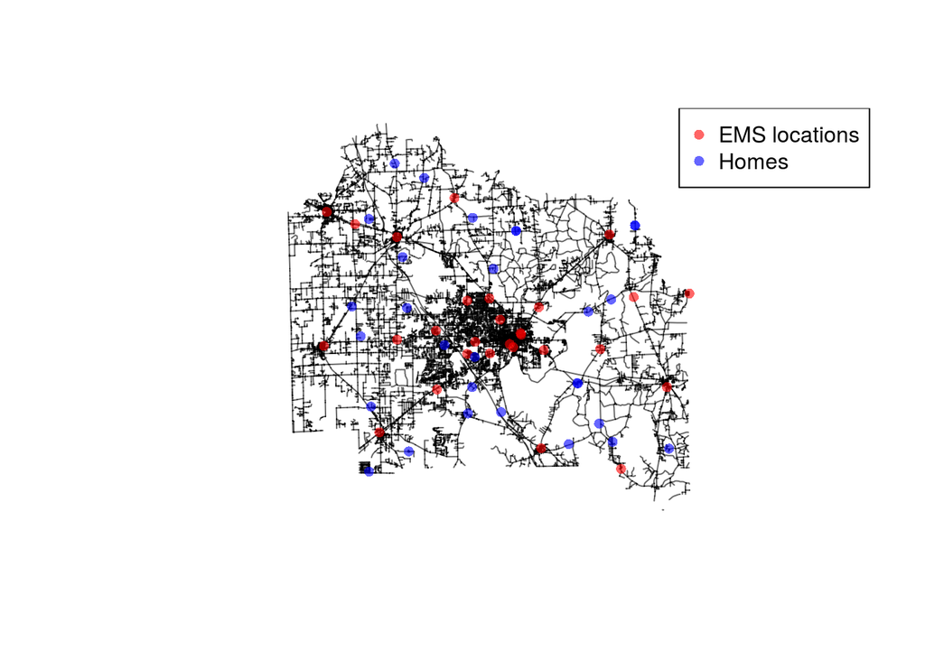

```r
plot(road, col = adjustcolor("black", alpha.f = 0.6))
points(ems, col = adjustcolor("red", alpha.f = 0.6), pch = 16)
points(fam, col = adjustcolor("blue", alpha.f = 0.6), pch = 16)
legend("topright", pch = 16, col = adjustcolor(c("red", "blue"), alpha.f = 0.6),
       legend = c("EMS locations", "Homes"))
```

Check what kind of unit of measurement we’re working with

```r
proj4string(ems) # US-FT
```

```
## [1] "+proj=lcc +lat_1=29.58333333333333 +lat_2=30.75 +lat_0=29 +lon_0=-84.5 +x_0=600000 +y_0=0 +datum=NAD83 +units=us-ft +no_defs +ellps=GRS80 +towgs84=0,0,0"
```

Merge our EMS and family points into one dataframe.

```r
fam_coords <- data.frame(cbind(coordinates(fam), group = "fam"), stringsAsFactors = FALSE)
ems_coords <- data.frame(cbind(coordinates(ems), group = "ems"), stringsAsFactors = FALSE)

# Create a list of the two collections of coordinates
x <- list(ems_coords, fam_coords)
# Bind all elementsin the list together
x <- do.call("rbind", x)
# Now we have x, a dataframe of the coordinates

# Make it spatial
x$coords.x1 <- as.numeric(x$coords.x1)
x$coords.x2 <- as.numeric(x$coords.x2)
coordinates(x) <- ~ coords.x1 + coords.x2
```

Replace ems/fam_coords with their spatial equivalents

```r
ems_coords <- x[which(x$group == "ems"),]
fam_coords <- x[which(x$group == "fam"),]
```

Write a function for calculating distance (in feet) using pythagorean theorem

```r
DistFun <- function(x, y, x2, y2){
  xdist <- sqrt((x - x2)^2)
  ydist <- sqrt((y - y2)^2)

  linedist <- sqrt((xdist^2) + (ydist^2))
  return(linedist)
}
```

Now loop that function over each address fam_coords to extract the index of the closest ems

```r
fam_coords$closest_ems_name <- vector(mode = "numeric", length = nrow(fam_coords))
fam_coords$closest_ems_distance <- vector(mode = "numeric", length = nrow(fam_coords))
fam_coords$closest_ems_index <- vector(mode = "numeric", length = nrow(fam_coords))

for (i in 1:nrow(fam_coords)){
  # Get the distance of every ems station from every address
  temp <- DistFun(x = coordinates(fam_coords)[i,1],
        y = coordinates(fam_coords)[i,2],
        x2 = coordinates(ems)[,1],
        y2 = coordinates(ems)[,2])
  # Extract the index number of the closest ems station
  best.ind <- which.min(temp)

  #Assign that index and distance to fam_coords
  fam_coords$closest_ems_index[i] <- best.ind
  fam_coords$closest_ems_name[i] <- as.character(ems$DESCRIPT[best.ind])
  fam_coords$closest_ems_distance[i] <- temp[which.min(temp)]

}

# Just for fun, let's make a miles column as well
fam_coords$closest_ems_miles <- fam_coords$closest_ems_distance / 5280

# Throw back in the object id
fam_coords$OBJECTID <- 1:nrow(fam_coords)
fam_coords$address <- fam$FULLADDR
```

Show the table with the closest EMS stations for each house.

```r
library(knitr)
z <- data.frame(fam_coords[,c("OBJECTID",
                         "address", "closest_ems_name",
                         "closest_ems_miles",
                         "closest_ems_index")])
# print(xtable(z), type = "html")
kable(z, format = "markdown", row.names = NA)
```

|  | OBJECTID | address | closest_ems_name | closest_ems_miles | closest_ems_index | coords.x1 | coords.x2 |
| --- | --- | --- | --- | --- | --- | --- | --- |
| 29 | 1 | 25702 NW COUNTY RD 241 | LA CROSSE VOLUNTEER FIRE DEPARTMENT | 6.3153 | 28 | 2603945 | 329466 |
| 30 | 2 | 23521 NW COUNTY RD 239 | LA CROSSE VOLUNTEER FIRE DEPARTMENT | 3.3239 | 28 | 2618196 | 322490 |
| 31 | 3 | 18028 NW 177TH AV | ALACHUA COUNTY FIRE RESCUE STATION 20 | 1.3578 | 16 | 2591490 | 302650 |
| 32 | 4 | 20972 NW 46TH AV | NEWBERRY FIRE RESCUE STATION 28 | 4.4141 | 8 | 2583276 | 260233 |
| 33 | 5 | 1407 NW 202ND ST | ALACHUA COUNTY FIRE RESCUE STATION 17 | 3.3497 | 9 | 2587505 | 245913 |
| 34 | 6 | 10860 NE STATE RD 26 | WINDSOR FIRE RESCUE | 3.6000 | 25 | 2697467 | 257798 |
| 35 | 7 | 14213 NE STATE RD 26 | ALACHUA COUNTY FIRE RESCUE STATION 25 | 2.0685 | 19 | 2708549 | 263743 |
| 36 | 8 | 1020 NE 156TH AV | LA CROSSE VOLUNTEER FIRE DEPARTMENT | 6.3844 | 28 | 2662560 | 296920 |
| 37 | 9 | 1028 NE 156TH AV | LA CROSSE VOLUNTEER FIRE DEPARTMENT | 6.3841 | 28 | 2662557 | 296917 |
| 38 | 10 | 3411 NW 177TH AV | LA CROSSE VOLUNTEER FIRE DEPARTMENT | 2.4634 | 28 | 2641619 | 303204 |
| 39 | 11 | 1815 NW 102ND PL | ALACHUA COUNTY FIRE RESCUE STATION 9 | 2.7420 | 20 | 2651666 | 278548 |
| 40 | 12 | 6410 SE 92ND TER | WINDSOR FIRE RESCUE | 3.7664 | 25 | 2692109 | 223241 |
| 41 | 13 | 6415 SE 92ND TER | WINDSOR FIRE RESCUE | 3.7468 | 25 | 2692512 | 223097 |
| 42 | 14 | 12318 S COUNTY RD 325 | ALACHUA COUNTY FIRE RESCUE STATION 31 | 4.6001 | 24 | 2702724 | 203613 |
| 43 | 15 | 7520 SE COUNTY RD 346 | MICANOPY FIRE DEPARTMENT STATION 26 | 2.5501 | 21 | 2688032 | 193745 |
| 44 | 16 | 10530 SW 12TH TER | MICANOPY FIRE DEPARTMENT STATION 26 | 4.9372 | 21 | 2655386 | 209246 |
| 45 | 17 | 4350 SW WACAHOOTA RD | ALACHUA COUNTY FIRE RESCUE STATION 15 | 3.5897 | 2 | 2639375 | 208594 |
| 46 | 18 | 4042 SW 69TH AV | ALACHUA COUNTY FIRE RESCUE STATION 19 | 3.0865 | 3 | 2641315 | 221303 |
| 47 | 19 | 2228 SW 37TH ST | ALACHUA COUNTY FIRE RESCUE STATION 19 | 0.7538 | 3 | 2642589 | 235868 |
| 48 | 20 | 7609 SW 4TH PL | ALACHUA COUNTY FIRE RESCUE STATION 16 | 1.5419 | 11 | 2628000 | 241664 |
| 49 | 21 | 4630 NW 129TH ST | ALACHUA COUNTY FIRE RESCUE STATION 17 | 3.0515 | 9 | 2609876 | 259681 |
| 50 | 22 | 12111 NW 136TH ST | ALACHUA COUNTY FIRE AND RESCUE STATION 21 | 1.9056 | 23 | 2607750 | 284221 |
| 51 | 23 | 12930 SW 159TH AV | ALACHUA COUNTY FIRE RESCUE | 3.2032 | 1 | 2610743 | 190216 |
| 52 | 24 | 18908 SW 186TH ST | ALACHUA COUNTY FIRE RESCUE | 3.7256 | 1 | 2591566 | 180479 |
| 53 | 25 | 18318 SW 95TH AV | ALACHUA COUNTY FIRE RESCUE | 2.4791 | 1 | 2592490 | 211921 |
| 54 | 26 | 16110 NE COUNTY RD 1471 | WALDO FIRE AND RESCUE STATION 23 | 2.4811 | 15 | 2720040 | 299516 |
| 55 | 27 | 16010 NE COUNTY RD 1471 | WALDO FIRE AND RESCUE STATION 23 | 2.4811 | 15 | 2720040 | 299516 |
| 56 | 28 | 22240 SE 162ND AV | ALACHUA COUNTY FIRE RESCUE STATION 31 | 4.7685 | 24 | 2736505 | 191576 |
| 57 | 29 | 13909 SE 152ND LN | ALACHUA COUNTY FIRE RESCUE STATION 31 | 2.6005 | 24 | 2709278 | 194881 |

# Task 2

## Use network analysis to estimate the shortest response time of an EMS (emergence medical service) to the family addresses following the in- class tutorials.

Steps: 1. Data Preparation: Assign travel time to road segment following the in- class tutorials; 2. Build Network Dataset; 3. Estimate shortest travel time 4. Note: Select “new OD Cost Matrix” from Network Analyst and Select “Family_house” as Origins and “EMS_Location” as Destinations. Please give a good screen shot to show your result.

I took an alternative approach to this problem. Using the ggmap package, I calculated the *true* travel time from every address to every EMS location. The advantage of this approach is that it takes into account travel times from Google’s API, rather than simply calculating speed limit (which likely underestimates true travel time).

First, I attach the ggmap library.

```r
library(ggmap)
```

Now, let’s get latitude and longitude for each point (so as to more smoothly interact with google’s API):

```r
#Get a projection string for both
proj4string(ems_coords) <- proj4string(ems)
proj4string(fam_coords) <- proj4string(ems)

#Convert to latitude / longitude
ems_latlon <- spTransform(ems_coords, CRS("+init=epsg:4326"))
fam_latlon <- spTransform(fam_coords, CRS("+init=epsg:4326"))
```

Then I write a function to wrap around ggmap’s mapdist() function

```r
TravelTime <- function(from, to){
  mapdist(from, to, mode = "driving")
}
```

Finally, I loop my TravelTime function over each row of the address points.

```r
# Create empty columns for our new variables
fam_coords$closest_ems_travel_time_minutes <- vector(mode = "numeric", length = nrow(fam_coords))
fam_coords$closest_ems_travel_distance_km <- vector(mode = "numeric", length = nrow(fam_coords))
fam_coords$closest_ems_travel_index <- vector(mode = "numeric", length = nrow(fam_coords))
fam_coords$closest_ems_travel_name <- vector(mode = "numeric", length = nrow(fam_coords))

#Loop through each row of family addresses, calculating distance/time from each ems
for (i in 1:nrow(fam_coords)){
  tofam <- paste0(coordinates(fam_latlon)[,2], ", ",coordinates(fam_latlon)[,1])[i]
  fromems <- paste0(coordinates(ems_latlon)[,2], ", ",coordinates(ems_latlon)[,1])

  x <- TravelTime(from = fromems,
             to = tofam)

 # Assing the index of the best (least time) ems station
  best.ind <- which.min(x$minutes)[1]

 # Put info back into fam_coords
fam_coords$closest_ems_travel_time_minutes[i] <- x$minutes[best.ind]
fam_coords$closest_ems_travel_distance_km[i] <- x$km[best.ind]
fam_coords$closest_ems_travel_index[i] <- best.ind
fam_coords$closest_ems_travel_name[i] <- as.character(ems$DESCRIPT[best.ind])

}
```

Show the table with the closest EMS stations for each house.

```r
library(knitr)
z <- data.frame(fam_coords[,c("OBJECTID",
                         "address", "closest_ems_travel_name",
                         "closest_ems_travel_distance_km",
                         "closest_ems_travel_time_minutes",
                         "closest_ems_index")])
# print(xtable(z), type = "html")
kable(z, format = "markdown", row.names = NA)
```

|  | OBJECTID | address | closest_ems_travel_name | closest_ems_travel_distance_km | closest_ems_travel_time_minutes | closest_ems_index | coords.x1 | coords.x2 |
| --- | --- | --- | --- | --- | --- | --- | --- | --- |
| 29 | 1 | 25702 NW COUNTY RD 241 | ALACHUA COUNTY FIRE AND RESCUE STATION 21 | 11.648 | 10.633 | 28 | 2603945 | 329466 |
| 30 | 2 | 23521 NW COUNTY RD 239 | LA CROSSE VOLUNTEER FIRE DEPARTMENT | 8.896 | 6.950 | 28 | 2618196 | 322490 |
| 31 | 3 | 18028 NW 177TH AV | ALACHUA COUNTY FIRE RESCUE STATION 20 | 7.386 | 7.367 | 16 | 2591490 | 302650 |
| 32 | 4 | 20972 NW 46TH AV | NEWBERRY FIRE RESCUE STATION 28 | 8.044 | 7.050 | 8 | 2583276 | 260233 |
| 33 | 5 | 1407 NW 202ND ST | ALACHUA COUNTY FIRE RESCUE STATION 17 | 7.287 | 6.350 | 9 | 2587505 | 245913 |
| 34 | 6 | 10860 NE STATE RD 26 | ALACHUA COUNTY FIRE RESCUE STATION 25 | 8.147 | 5.817 | 25 | 2697467 | 257798 |
| 35 | 7 | 14213 NE STATE RD 26 | ALACHUA COUNTY FIRE RESCUE STATION 25 | 4.457 | 3.550 | 19 | 2708549 | 263743 |
| 36 | 8 | 1020 NE 156TH AV | LA CROSSE VOLUNTEER FIRE DEPARTMENT | 13.882 | 9.700 | 28 | 2662560 | 296920 |
| 37 | 9 | 1028 NE 156TH AV | LA CROSSE VOLUNTEER FIRE DEPARTMENT | 13.882 | 9.700 | 28 | 2662557 | 296917 |
| 38 | 10 | 3411 NW 177TH AV | LA CROSSE VOLUNTEER FIRE DEPARTMENT | 4.480 | 4.733 | 28 | 2641619 | 303204 |
| 39 | 11 | 1815 NW 102ND PL | ALACHUA COUNTY FIRE RESCUE STATION 9 | 5.187 | 4.950 | 20 | 2651666 | 278548 |
| 40 | 12 | 6410 SE 92ND TER | WINDSOR FIRE RESCUE | 6.150 | 6.417 | 25 | 2692109 | 223241 |
| 41 | 13 | 6415 SE 92ND TER | WINDSOR FIRE RESCUE | 6.051 | 6.067 | 25 | 2692512 | 223097 |
| 42 | 14 | 12318 S COUNTY RD 325 | ALACHUA COUNTY FIRE RESCUE STATION 31 | 8.135 | 6.033 | 24 | 2702724 | 203613 |
| 43 | 15 | 7520 SE COUNTY RD 346 | MICANOPY FIRE DEPARTMENT STATION 26 | 4.711 | 4.717 | 21 | 2688032 | 193745 |
| 44 | 16 | 10530 SW 12TH TER | MICANOPY FIRE DEPARTMENT STATION 26 | 8.989 | 8.000 | 21 | 2655386 | 209246 |
| 45 | 17 | 4350 SW WACAHOOTA RD | ALACHUA COUNTY FIRE RESCUE STATION 15 | 9.239 | 8.567 | 2 | 2639375 | 208594 |
| 46 | 18 | 4042 SW 69TH AV | ALACHUA COUNTY FIRE RESCUE STATION 19 | 6.247 | 8.383 | 3 | 2641315 | 221303 |
| 47 | 19 | 2228 SW 37TH ST | ALACHUA COUNTY FIRE RESCUE STATION 19 | 1.181 | 2.167 | 3 | 2642589 | 235868 |
| 48 | 20 | 7609 SW 4TH PL | ALACHUA COUNTY FIRE RESCUE STATION 16 | 3.611 | 5.367 | 11 | 2628000 | 241664 |
| 49 | 21 | 4630 NW 129TH ST | ALACHUA COUNTY FIRE RESCUE STATION 17 | 6.256 | 6.550 | 9 | 2609876 | 259681 |
| 50 | 22 | 12111 NW 136TH ST | ALACHUA COUNTY FIRE AND RESCUE STATION 21 | 5.854 | 7.700 | 23 | 2607750 | 284221 |
| 51 | 23 | 12930 SW 159TH AV | ALACHUA COUNTY FIRE RESCUE | 6.862 | 8.533 | 1 | 2610743 | 190216 |
| 52 | 24 | 18908 SW 186TH ST | ALACHUA COUNTY FIRE RESCUE | 8.164 | 9.367 | 1 | 2591566 | 180479 |
| 53 | 25 | 18318 SW 95TH AV | ALACHUA COUNTY FIRE RESCUE | 4.976 | 4.667 | 1 | 2592490 | 211921 |
| 54 | 26 | 16110 NE COUNTY RD 1471 | ALACHUA COUNTY FIRE RESCUE STATION 25 | 11.160 | 7.683 | 15 | 2720040 | 299516 |
| 55 | 27 | 16010 NE COUNTY RD 1471 | ALACHUA COUNTY FIRE RESCUE STATION 25 | 11.160 | 7.683 | 15 | 2720040 | 299516 |
| 56 | 28 | 22240 SE 162ND AV | CITY OF HAWTHORNE FIRE AND RESCUE | 10.624 | 8.550 | 24 | 2736505 | 191576 |
| 57 | 29 | 13909 SE 152ND LN | ALACHUA COUNTY FIRE RESCUE STATION 31 | 4.898 | 4.283 | 24 | 2709278 | 194881 |

Note that there is a correlation between distance and time, but it’s not perfectly linear.

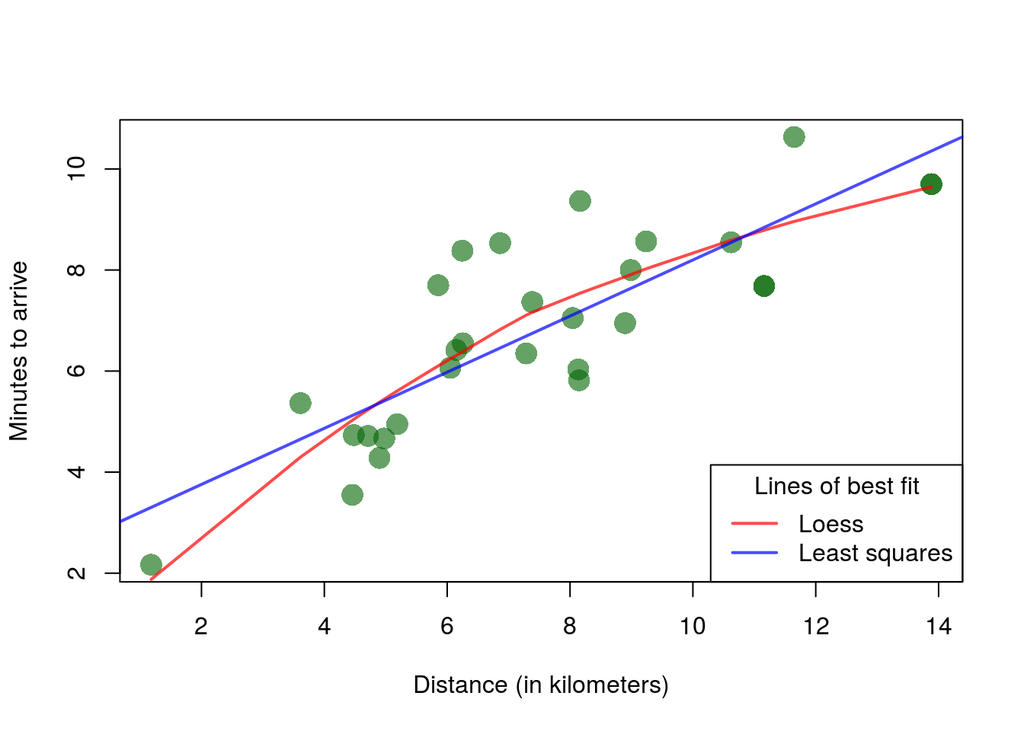

```r
plot(fam_coords$closest_ems_travel_distance_km,
     fam_coords$closest_ems_travel_time_minutes,
     xlab = "Distance (in kilometers)",
     ylab = "Minutes to arrive",
     pch = 16,
     col = adjustcolor("darkgreen", alpha.f = 0.6),
     cex = 2)

  #ADD LOESS LINE
  lox <- fam_coords$closest_ems_travel_distance_km
  loy <- fam_coords$closest_ems_travel_time_minutes
  lw1 <- loess(loy ~ lox, span=1)
  j <- order(lox)
  lines(lox[j],lw1$fitted[j],col=adjustcolor("red", alpha.f = 0.7),
        lty=1,
        lwd = 2)

# ADD Regression line
fit <- lm(loy ~ lox)
abline(fit, col = adjustcolor("blue", alpha.f = 0.7),
       lwd = 2)
legend("bottomright",
       col = adjustcolor(c("red", "blue"), alpha.f = 0.7),
       lty = 1,
       lwd = 2,
       legend = c("Loess", "Least squares"),
       title = "Lines of best fit")
```

Just for fun, let’s plot the family addresses with their color being a function of the time they are from an EMS response (red being slow, blue being fast).

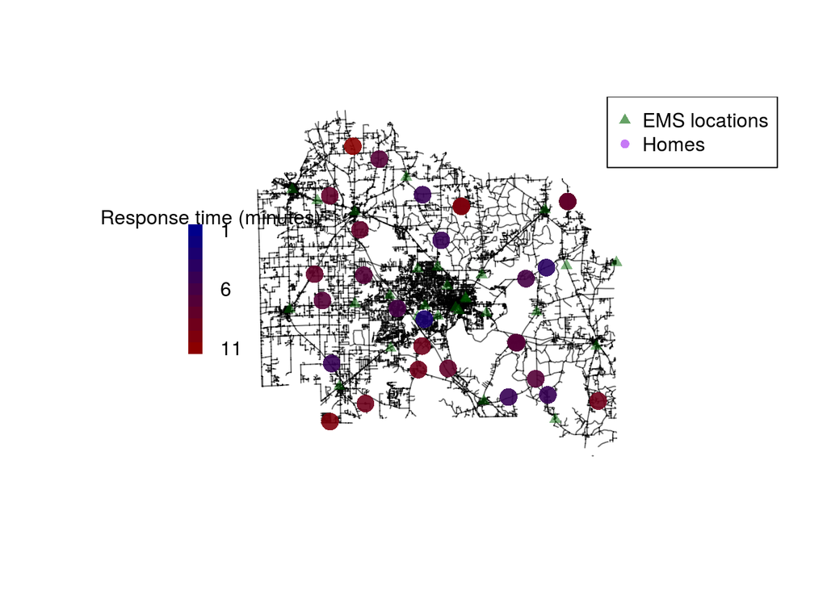

```r
library(RColorBrewer)
my_colors <- colorRampPalette(c("darkblue", "darkred"))(ceiling(max(fam_coords$closest_ems_travel_time_minutes)))
fam_coords$color <- my_colors[ceiling(fam_coords$closest_ems_travel_time_minutes)]

plot(road, col = adjustcolor("black", alpha.f = 0.6))
points(ems, col = adjustcolor("darkgreen", alpha.f = 0.5), pch = 17)
points(fam, col = adjustcolor(fam_coords$color, alpha.f = 0.9), pch = 16, cex = 2)
legend("topright", pch = c(17,16), col = adjustcolor(c("darkgreen", "purple"), alpha.f = 0.6),
       legend = c("EMS locations", "Homes"))
legend("left", fill = my_colors, bty = "n",
       y.intersp = 0.5, ncol=1, legend=c(1, rep(NA, 4), 6, rep(NA, 4), 11),
       border = NA, title = "Response time (minutes)")
```

Here’s the code for an interactive map (if you run this on your own computer)

```r
library(rCharts)

# read in geojson version of zip
#zip_geoj <- readOGR("zips_alachua", "ACDPS_zipcode")
mymap <- Leaflet$new()
mymap$tileLayer(provider = "Stamen.TonerLite")
mymap$setView(c(29.65, -82.3), zoom = 10)
mymap$enablePopover(TRUE)


library(rCharts)
library(rMaps)
mywaypoints = list(c(40.74119, -73.9925), c(40.73573, -73.99302))


mywaypoints <- list()
for (i in 1:nrow(fam_coords)){
  mywaypoints[[i]] <- (c(as.numeric(coordinates(fam_latlon)[i,2]),
                 as.numeric(coordinates(fam_latlon)[i,1])))

}


mymap$addAssets(
  css = "http://www.liedman.net/leaflet-routing-machine/dist/leaflet-routing-machine.css",
  jshead = "http://www.liedman.net/leaflet-routing-machine/dist/leaflet-routing-machine.min.js"
)

routingTemplate = "
 <script>
 var mywaypoints = %s
 L.Routing.control({
  waypoints: [
    L.latLng.apply(null, mywaypoints[0]),
    L.latLng.apply(null, mywaypoints[1])
  ]
 }).addTo(mymap);
 </script>"

mymap$setTemplate(
  afterScript = sprintf(routingTemplate, RJSONIO::toJSON(mywaypoints))
)
mymap$set(width = 1450, height = 800)

mymap

#mymap$fullScreen(TRUE)

# for (i in 1:nrow(fam_coords)){
#   mymap$marker(c(as.numeric(coordinates(fam_latlon)[i,2]),
#                  as.numeric(coordinates(fam_latlon)[i,1])),
#                bindPopup = paste(round(fam_coords$closest_ems_travel_time_minutes[i], digits=1), "minutes for",
#                                  fam_coords$closest_ems_travel_name[i], "to respond to",
#                                  fam_coords$address[i]
#                                  ))
#
# }

#library(shiny)
# renderMap(mymap)
```